# final_report

Jacob Bailey.1665

2024-12-01

# Part 1: Exploratory Data Analysis

```r
# read data in
train_data = read.csv('train.csv')
test_data = read.csv('test.csv')

# combine data for transformations
combined_data = rbind(train_data, test_data)

num_training = 1460

# drop Id
combined_data['Id'] = NULL

# summary of data
library(skimr)
skim(combined_data)
```

Data summary

| Name | combined_data |
| --- | --- |
| Number of rows | 2907 |
| Number of columns | 80 |
| _______________________ |  |
| Column type frequency: |  |
| character | 43 |
| numeric | 37 |
| ________________________ |  |
| Group variables | None |

**Variable type: character**

| skim_variable | n_missing | complete_rate | min | max | empty | n_unique | whitespace |
| --- | --- | --- | --- | --- | --- | --- | --- |
| MSZoning | 0 | 1.00 | 2 | 7 | 0 | 5 | 0 |
| Street | 0 | 1.00 | 4 | 4 | 0 | 2 | 0 |
| Alley | 2710 | 0.07 | 4 | 4 | 0 | 2 | 0 |
| LotShape | 0 | 1.00 | 3 | 3 | 0 | 4 | 0 |
| LandContour | 0 | 1.00 | 3 | 3 | 0 | 4 | 0 |
| Utilities | 1 | 1.00 | 6 | 6 | 0 | 2 | 0 |
| LotConfig | 0 | 1.00 | 3 | 7 | 0 | 5 | 0 |
| LandSlope | 0 | 1.00 | 3 | 3 | 0 | 3 | 0 |
| Neighborhood | 0 | 1.00 | 5 | 7 | 0 | 25 | 0 |
| Condition1 | 0 | 1.00 | 4 | 6 | 0 | 9 | 0 |
| Condition2 | 0 | 1.00 | 4 | 6 | 0 | 8 | 0 |
| BldgType | 0 | 1.00 | 4 | 6 | 0 | 5 | 0 |
| HouseStyle | 0 | 1.00 | 4 | 6 | 0 | 8 | 0 |
| RoofStyle | 0 | 1.00 | 3 | 7 | 0 | 6 | 0 |
| RoofMatl | 0 | 1.00 | 4 | 7 | 0 | 8 | 0 |
| Exterior1st | 0 | 1.00 | 5 | 7 | 0 | 15 | 0 |
| Exterior2nd | 0 | 1.00 | 5 | 7 | 0 | 16 | 0 |
| MasVnrType | 24 | 0.99 | 4 | 7 | 0 | 4 | 0 |
| ExterQual | 0 | 1.00 | 2 | 2 | 0 | 4 | 0 |
| ExterCond | 0 | 1.00 | 2 | 2 | 0 | 5 | 0 |
| Foundation | 0 | 1.00 | 4 | 6 | 0 | 6 | 0 |
| BsmtQual | 77 | 0.97 | 2 | 2 | 0 | 4 | 0 |
| BsmtCond | 75 | 0.97 | 2 | 2 | 0 | 4 | 0 |
| BsmtExposure | 78 | 0.97 | 2 | 2 | 0 | 4 | 0 |
| BsmtFinType1 | 75 | 0.97 | 3 | 3 | 0 | 6 | 0 |
| BsmtFinType2 | 76 | 0.97 | 3 | 3 | 0 | 6 | 0 |
| Heating | 0 | 1.00 | 4 | 5 | 0 | 6 | 0 |
| HeatingQC | 0 | 1.00 | 2 | 2 | 0 | 5 | 0 |
| CentralAir | 0 | 1.00 | 1 | 1 | 0 | 2 | 0 |
| Electrical | 1 | 1.00 | 3 | 5 | 0 | 5 | 0 |
| KitchenQual | 1 | 1.00 | 2 | 2 | 0 | 4 | 0 |
| Functional | 1 | 1.00 | 3 | 4 | 0 | 7 | 0 |
| FireplaceQu | 1412 | 0.51 | 2 | 2 | 0 | 5 | 0 |
| GarageType | 156 | 0.95 | 6 | 7 | 0 | 6 | 0 |
| GarageFinish | 157 | 0.95 | 3 | 3 | 0 | 3 | 0 |
| GarageQual | 157 | 0.95 | 2 | 2 | 0 | 5 | 0 |
| GarageCond | 157 | 0.95 | 2 | 2 | 0 | 5 | 0 |
| PavedDrive | 0 | 1.00 | 1 | 1 | 0 | 3 | 0 |
| PoolQC | 2897 | 0.00 | 2 | 2 | 0 | 3 | 0 |
| Fence | 2340 | 0.20 | 4 | 5 | 0 | 4 | 0 |
| MiscFeature | 2802 | 0.04 | 4 | 4 | 0 | 4 | 0 |
| SaleType | 1 | 1.00 | 2 | 5 | 0 | 9 | 0 |
| SaleCondition | 0 | 1.00 | 6 | 7 | 0 | 6 | 0 |

**Variable type: numeric**

| skim_variable | n_missing | complete_rate | mean | sd | p0 | p25 | p50 | p75 | p100 | hist |
| --- | --- | --- | --- | --- | --- | --- | --- | --- | --- | --- |
| MSSubClass | 0 | 1.00 | 57.13 | 42.48 | 20 | 20 | 50 | 70.0 | 190 | ▇▅▂▁▁ |
| LotFrontage | 485 | 0.83 | 69.28 | 23.30 | 21 | 59 | 68 | 80.0 | 313 | ▇▃▁▁▁ |
| LotArea | 0 | 1.00 | 10142.55 | 7836.99 | 1300 | 7484 | 9452 | 11554.5 | 215245 | ▇▁▁▁▁ |
| OverallQual | 0 | 1.00 | 6.09 | 1.40 | 1 | 5 | 6 | 7.0 | 10 | ▁▂▇▅▁ |
| OverallCond | 0 | 1.00 | 5.57 | 1.11 | 1 | 5 | 5 | 6.0 | 9 | ▁▁▇▅▁ |
| YearBuilt | 0 | 1.00 | 1971.38 | 30.26 | 1872 | 1954 | 1973 | 2001.0 | 2010 | ▁▂▃▆▇ |
| YearRemodAdd | 0 | 1.00 | 1984.29 | 20.87 | 1950 | 1965 | 1993 | 2004.0 | 2010 | ▅▂▂▃▇ |
| MasVnrArea | 23 | 0.99 | 102.56 | 179.61 | 0 | 0 | 0 | 165.0 | 1600 | ▇▁▁▁▁ |
| BsmtFinSF1 | 0 | 1.00 | 441.57 | 455.59 | 0 | 0 | 369 | 733.0 | 5644 | ▇▁▁▁▁ |
| BsmtFinSF2 | 0 | 1.00 | 49.64 | 169.39 | 0 | 0 | 0 | 0.0 | 1526 | ▇▁▁▁▁ |
| BsmtUnfSF | 0 | 1.00 | 561.71 | 439.66 | 0 | 221 | 468 | 807.0 | 2336 | ▇▅▂▁▁ |
| TotalBsmtSF | 0 | 1.00 | 1052.92 | 439.99 | 0 | 793 | 990 | 1302.0 | 6110 | ▇▃▁▁▁ |
| X1stFlrSF | 0 | 1.00 | 1159.92 | 392.53 | 334 | 876 | 1083 | 1387.5 | 5095 | ▇▃▁▁▁ |
| X2ndFlrSF | 0 | 1.00 | 336.86 | 428.95 | 0 | 0 | 0 | 704.0 | 2065 | ▇▃▂▁▁ |
| LowQualFinSF | 0 | 1.00 | 4.69 | 46.47 | 0 | 0 | 0 | 0.0 | 1064 | ▇▁▁▁▁ |
| GrLivArea | 0 | 1.00 | 1501.46 | 506.35 | 334 | 1126 | 1444 | 1745.0 | 5642 | ▇▇▁▁▁ |
| BsmtFullBath | 1 | 1.00 | 0.43 | 0.52 | 0 | 0 | 0 | 1.0 | 3 | ▇▆▁▁▁ |
| BsmtHalfBath | 1 | 1.00 | 0.06 | 0.25 | 0 | 0 | 0 | 0.0 | 2 | ▇▁▁▁▁ |
| FullBath | 0 | 1.00 | 1.57 | 0.55 | 0 | 1 | 2 | 2.0 | 4 | ▁▇▇▁▁ |
| HalfBath | 0 | 1.00 | 0.38 | 0.50 | 0 | 0 | 0 | 1.0 | 2 | ▇▁▅▁▁ |
| BedroomAbvGr | 0 | 1.00 | 2.86 | 0.82 | 0 | 2 | 3 | 3.0 | 8 | ▁▇▂▁▁ |
| KitchenAbvGr | 0 | 1.00 | 1.04 | 0.21 | 0 | 1 | 1 | 1.0 | 3 | ▁▇▁▁▁ |
| TotRmsAbvGrd | 0 | 1.00 | 6.46 | 1.57 | 2 | 5 | 6 | 7.0 | 15 | ▁▇▂▁▁ |
| Fireplaces | 0 | 1.00 | 0.60 | 0.65 | 0 | 0 | 1 | 1.0 | 4 | ▇▇▁▁▁ |
| GarageYrBlt | 157 | 0.95 | 1978.15 | 25.55 | 1895 | 1960 | 1979 | 2002.0 | 2207 | ▂▇▁▁▁ |
| GarageCars | 0 | 1.00 | 1.77 | 0.76 | 0 | 1 | 2 | 2.0 | 5 | ▅▇▂▁▁ |
| GarageArea | 0 | 1.00 | 473.26 | 215.48 | 0 | 321 | 480 | 576.0 | 1488 | ▃▇▃▁▁ |
| WoodDeckSF | 0 | 1.00 | 93.90 | 126.62 | 0 | 0 | 0 | 168.0 | 1424 | ▇▁▁▁▁ |
| OpenPorchSF | 0 | 1.00 | 47.56 | 67.63 | 0 | 0 | 27 | 70.0 | 742 | ▇▁▁▁▁ |
| EnclosedPorch | 0 | 1.00 | 23.03 | 64.20 | 0 | 0 | 0 | 0.0 | 1012 | ▇▁▁▁▁ |
| X3SsnPorch | 0 | 1.00 | 2.61 | 25.24 | 0 | 0 | 0 | 0.0 | 508 | ▇▁▁▁▁ |
| ScreenPorch | 0 | 1.00 | 16.13 | 56.29 | 0 | 0 | 0 | 0.0 | 576 | ▇▁▁▁▁ |
| PoolArea | 0 | 1.00 | 2.26 | 35.74 | 0 | 0 | 0 | 0.0 | 800 | ▇▁▁▁▁ |
| MiscVal | 0 | 1.00 | 51.04 | 568.56 | 0 | 0 | 0 | 0.0 | 17000 | ▇▁▁▁▁ |
| MoSold | 0 | 1.00 | 6.22 | 2.71 | 1 | 4 | 6 | 8.0 | 12 | ▅▆▇▃▃ |
| YrSold | 0 | 1.00 | 2007.79 | 1.32 | 2006 | 2007 | 2008 | 2009.0 | 2010 | ▇▇▇▇▃ |
| SalePrice | 0 | 1.00 | 180898.92 | 79932.19 | 12789 | 129500 | 160000 | 213500.0 | 755000 | ▇▇▁▁▁ |

After initially examining the dataset, we can see there are many ‘null’ categorical values. However, many of them shown as ‘null’ are in fact representing a category such as ‘None’ for a given categorical predictor. Values such as these will be transformed to more meaningful, non-null categories below. For example if ‘GarageQual’ is null, it will become ‘NoGarage’.

```r
# Replace NA in Alley with "NoAccess"
combined_data$Alley[is.na(combined_data$Alley)] <- "NoAccess"

# One missing value in 'Utilities', but supposed to be no nulls. We will drop it
combined_data <- subset(combined_data, !is.na(Utilities))

# Replace MasVnrType nulls with 'None'
combined_data$MasVnrType[is.na(combined_data$MasVnrType)] <- "None"

# Replace BsmtQual, BsmtCond, BsmtExposure, BsmtFinType1, BsmtFinType2  nulls with 'NoBasement'
combined_data$BsmtQual[is.na(combined_data$BsmtQual)] <- "NoBasement"
combined_data$BsmtCond[is.na(combined_data$BsmtCond)] <- "NoBasement"
combined_data$BsmtExposure[is.na(combined_data$BsmtExposure)] <- "NoBasement"
combined_data$BsmtFinType1[is.na(combined_data$BsmtFinType1)] <- "NoBasement"
combined_data$BsmtFinType2[is.na(combined_data$BsmtFinType2)] <- "NoBasement"

# One missing value in 'Electrical', but supposed to be no nulls. We will drop it
combined_data <- subset(combined_data, !is.na(Electrical))

# One missing value in 'KitchenQual', but supposed to be no nulls. We will drop it
combined_data <- subset(combined_data, !is.na(KitchenQual))

# One missing value in 'Functional', but supposed to be no nulls. We will drop it
combined_data <- subset(combined_data, !is.na(Functional))

# Replace FireplaceQu nulls with 'NoFireplace'
combined_data$FireplaceQu[is.na(combined_data$FireplaceQu)] <- "NoFireplace"

# Replace GarageType, GarageFinish, GarageQual, GarageCond nulls with 'NoGarage'
combined_data$GarageType[is.na(combined_data$GarageType)] <- "NoGarage"
combined_data$GarageFinish[is.na(combined_data$GarageFinish)] <- "NoGarage"
combined_data$GarageQual[is.na(combined_data$GarageQual)] <- "NoGarage"
combined_data$GarageCond[is.na(combined_data$GarageCond)] <- "NoGarage"

# Replace PoolQC nulls with 'NoPool'
combined_data$PoolQC[is.na(combined_data$PoolQC)] <- "NoPool"

# Replace Fence nulls with 'NoFence'
combined_data$Fence[is.na(combined_data$Fence)] <- "NoFence"

# Replace MiscFeature nulls with 'None'
combined_data$MiscFeature[is.na(combined_data$MiscFeature)] <- "None"

# Replace SaleType nulls with 'Other'
combined_data$SaleType[is.na(combined_data$SaleType)] <- "Other"
```

There are not many numerical null values, but for the ones that are, we will replace with the median value of that column to prevent any skew of the predictor to influence this estimate.

```r
# Impute LotFrontage with the median
combined_data$LotFrontage[is.na(combined_data$LotFrontage)] <- median(combined_data$LotFrontage, na.rm = TRUE)

# Impute MasVnrArea with the median
combined_data$MasVnrArea[is.na(combined_data$MasVnrArea)] <- median(combined_data$MasVnrArea, na.rm = TRUE)

# Impute BsmtFullBath with the median
combined_data$BsmtFullBath[is.na(combined_data$BsmtFullBath)] <- median(combined_data$BsmtFullBath, na.rm = TRUE)

# Impute BsmtHalfBath with the median
combined_data$BsmtHalfBath[is.na(combined_data$BsmtHalfBath)] <- median(combined_data$BsmtHalfBath, na.rm = TRUE)

# Impute GarageYrBlt with the median
combined_data$GarageYrBlt[is.na(combined_data$GarageYrBlt)] <- median(combined_data$GarageYrBlt, na.rm = TRUE)
```

Now we’ll make sure the data is complete

```r
skim(combined_data)
```

Data summary

| Name | combined_data |
| --- | --- |
| Number of rows | 2903 |
| Number of columns | 80 |
| _______________________ |  |
| Column type frequency: |  |
| character | 43 |
| numeric | 37 |
| ________________________ |  |
| Group variables | None |

**Variable type: character**

| skim_variable | n_missing | complete_rate | min | max | empty | n_unique | whitespace |
| --- | --- | --- | --- | --- | --- | --- | --- |
| MSZoning | 0 | 1 | 2 | 7 | 0 | 5 | 0 |
| Street | 0 | 1 | 4 | 4 | 0 | 2 | 0 |
| Alley | 0 | 1 | 4 | 8 | 0 | 3 | 0 |
| LotShape | 0 | 1 | 3 | 3 | 0 | 4 | 0 |
| LandContour | 0 | 1 | 3 | 3 | 0 | 4 | 0 |
| Utilities | 0 | 1 | 6 | 6 | 0 | 2 | 0 |
| LotConfig | 0 | 1 | 3 | 7 | 0 | 5 | 0 |
| LandSlope | 0 | 1 | 3 | 3 | 0 | 3 | 0 |
| Neighborhood | 0 | 1 | 5 | 7 | 0 | 25 | 0 |
| Condition1 | 0 | 1 | 4 | 6 | 0 | 9 | 0 |
| Condition2 | 0 | 1 | 4 | 6 | 0 | 8 | 0 |
| BldgType | 0 | 1 | 4 | 6 | 0 | 5 | 0 |
| HouseStyle | 0 | 1 | 4 | 6 | 0 | 8 | 0 |
| RoofStyle | 0 | 1 | 3 | 7 | 0 | 6 | 0 |
| RoofMatl | 0 | 1 | 4 | 7 | 0 | 8 | 0 |
| Exterior1st | 0 | 1 | 5 | 7 | 0 | 15 | 0 |
| Exterior2nd | 0 | 1 | 5 | 7 | 0 | 16 | 0 |
| MasVnrType | 0 | 1 | 4 | 7 | 0 | 4 | 0 |
| ExterQual | 0 | 1 | 2 | 2 | 0 | 4 | 0 |
| ExterCond | 0 | 1 | 2 | 2 | 0 | 5 | 0 |
| Foundation | 0 | 1 | 4 | 6 | 0 | 6 | 0 |
| BsmtQual | 0 | 1 | 2 | 10 | 0 | 5 | 0 |
| BsmtCond | 0 | 1 | 2 | 10 | 0 | 5 | 0 |
| BsmtExposure | 0 | 1 | 2 | 10 | 0 | 5 | 0 |
| BsmtFinType1 | 0 | 1 | 3 | 10 | 0 | 7 | 0 |
| BsmtFinType2 | 0 | 1 | 3 | 10 | 0 | 7 | 0 |
| Heating | 0 | 1 | 4 | 5 | 0 | 6 | 0 |
| HeatingQC | 0 | 1 | 2 | 2 | 0 | 5 | 0 |
| CentralAir | 0 | 1 | 1 | 1 | 0 | 2 | 0 |
| Electrical | 0 | 1 | 3 | 5 | 0 | 5 | 0 |
| KitchenQual | 0 | 1 | 2 | 2 | 0 | 4 | 0 |
| Functional | 0 | 1 | 3 | 4 | 0 | 7 | 0 |
| FireplaceQu | 0 | 1 | 2 | 11 | 0 | 6 | 0 |
| GarageType | 0 | 1 | 6 | 8 | 0 | 7 | 0 |
| GarageFinish | 0 | 1 | 3 | 8 | 0 | 4 | 0 |
| GarageQual | 0 | 1 | 2 | 8 | 0 | 6 | 0 |
| GarageCond | 0 | 1 | 2 | 8 | 0 | 6 | 0 |
| PavedDrive | 0 | 1 | 1 | 1 | 0 | 3 | 0 |
| PoolQC | 0 | 1 | 2 | 6 | 0 | 4 | 0 |
| Fence | 0 | 1 | 4 | 7 | 0 | 5 | 0 |
| MiscFeature | 0 | 1 | 4 | 4 | 0 | 5 | 0 |
| SaleType | 0 | 1 | 2 | 5 | 0 | 10 | 0 |
| SaleCondition | 0 | 1 | 6 | 7 | 0 | 6 | 0 |

**Variable type: numeric**

| skim_variable | n_missing | complete_rate | mean | sd | p0 | p25 | p50 | p75 | p100 | hist |
| --- | --- | --- | --- | --- | --- | --- | --- | --- | --- | --- |
| MSSubClass | 0 | 1 | 57.14 | 42.50 | 20 | 20.0 | 50 | 70.0 | 190 | ▇▅▂▁▁ |
| LotFrontage | 0 | 1 | 69.06 | 21.28 | 21 | 60.0 | 68 | 78.0 | 313 | ▇▂▁▁▁ |
| LotArea | 0 | 1 | 10135.20 | 7832.61 | 1300 | 7478.0 | 9450 | 11554.5 | 215245 | ▇▁▁▁▁ |
| OverallQual | 0 | 1 | 6.10 | 1.40 | 1 | 5.0 | 6 | 7.0 | 10 | ▁▂▇▅▁ |
| OverallCond | 0 | 1 | 5.57 | 1.10 | 1 | 5.0 | 5 | 6.0 | 9 | ▁▁▇▅▁ |
| YearBuilt | 0 | 1 | 1971.41 | 30.24 | 1872 | 1954.0 | 1973 | 2001.0 | 2010 | ▁▂▃▆▇ |
| YearRemodAdd | 0 | 1 | 1984.32 | 20.85 | 1950 | 1965.0 | 1993 | 2004.0 | 2010 | ▅▂▂▃▇ |
| MasVnrArea | 0 | 1 | 101.89 | 179.21 | 0 | 0.0 | 0 | 164.0 | 1600 | ▇▁▁▁▁ |
| BsmtFinSF1 | 0 | 1 | 442.18 | 455.61 | 0 | 0.0 | 370 | 733.0 | 5644 | ▇▁▁▁▁ |
| BsmtFinSF2 | 0 | 1 | 49.71 | 169.50 | 0 | 0.0 | 0 | 0.0 | 1526 | ▇▁▁▁▁ |
| BsmtUnfSF | 0 | 1 | 561.29 | 439.48 | 0 | 220.5 | 467 | 807.0 | 2336 | ▇▅▂▁▁ |
| TotalBsmtSF | 0 | 1 | 1053.18 | 439.90 | 0 | 793.0 | 990 | 1302.0 | 6110 | ▇▃▁▁▁ |
| X1stFlrSF | 0 | 1 | 1160.20 | 392.56 | 334 | 877.5 | 1084 | 1387.5 | 5095 | ▇▃▁▁▁ |
| X2ndFlrSF | 0 | 1 | 336.76 | 429.15 | 0 | 0.0 | 0 | 705.5 | 2065 | ▇▃▂▁▁ |
| LowQualFinSF | 0 | 1 | 4.65 | 46.46 | 0 | 0.0 | 0 | 0.0 | 1064 | ▇▁▁▁▁ |
| GrLivArea | 0 | 1 | 1501.61 | 506.67 | 334 | 1126.0 | 1444 | 1746.0 | 5642 | ▇▇▁▁▁ |
| BsmtFullBath | 0 | 1 | 0.43 | 0.53 | 0 | 0.0 | 0 | 1.0 | 3 | ▇▆▁▁▁ |
| BsmtHalfBath | 0 | 1 | 0.06 | 0.25 | 0 | 0.0 | 0 | 0.0 | 2 | ▇▁▁▁▁ |
| FullBath | 0 | 1 | 1.57 | 0.55 | 0 | 1.0 | 2 | 2.0 | 4 | ▁▇▇▁▁ |
| HalfBath | 0 | 1 | 0.38 | 0.50 | 0 | 0.0 | 0 | 1.0 | 2 | ▇▁▅▁▁ |
| BedroomAbvGr | 0 | 1 | 2.86 | 0.82 | 0 | 2.0 | 3 | 3.0 | 8 | ▁▇▂▁▁ |
| KitchenAbvGr | 0 | 1 | 1.04 | 0.22 | 0 | 1.0 | 1 | 1.0 | 3 | ▁▇▁▁▁ |
| TotRmsAbvGrd | 0 | 1 | 6.46 | 1.57 | 2 | 5.0 | 6 | 7.0 | 15 | ▁▇▂▁▁ |
| Fireplaces | 0 | 1 | 0.60 | 0.65 | 0 | 0.0 | 1 | 1.0 | 4 | ▇▇▁▁▁ |
| GarageYrBlt | 0 | 1 | 1978.24 | 24.80 | 1895 | 1962.0 | 1979 | 2001.0 | 2207 | ▂▇▁▁▁ |
| GarageCars | 0 | 1 | 1.77 | 0.76 | 0 | 1.0 | 2 | 2.0 | 5 | ▅▇▂▁▁ |
| GarageArea | 0 | 1 | 473.45 | 215.52 | 0 | 322.0 | 480 | 576.0 | 1488 | ▃▇▃▁▁ |
| WoodDeckSF | 0 | 1 | 93.99 | 126.68 | 0 | 0.0 | 0 | 168.0 | 1424 | ▇▁▁▁▁ |
| OpenPorchSF | 0 | 1 | 47.55 | 67.59 | 0 | 0.0 | 27 | 70.0 | 742 | ▇▁▁▁▁ |
| EnclosedPorch | 0 | 1 | 22.92 | 64.07 | 0 | 0.0 | 0 | 0.0 | 1012 | ▇▁▁▁▁ |
| X3SsnPorch | 0 | 1 | 2.62 | 25.26 | 0 | 0.0 | 0 | 0.0 | 508 | ▇▁▁▁▁ |
| ScreenPorch | 0 | 1 | 16.12 | 56.31 | 0 | 0.0 | 0 | 0.0 | 576 | ▇▁▁▁▁ |
| PoolArea | 0 | 1 | 2.26 | 35.76 | 0 | 0.0 | 0 | 0.0 | 800 | ▇▁▁▁▁ |
| MiscVal | 0 | 1 | 50.85 | 568.80 | 0 | 0.0 | 0 | 0.0 | 17000 | ▇▁▁▁▁ |
| MoSold | 0 | 1 | 6.22 | 2.71 | 1 | 4.0 | 6 | 8.0 | 12 | ▅▆▇▃▃ |
| YrSold | 0 | 1 | 2007.79 | 1.32 | 2006 | 2007.0 | 2008 | 2009.0 | 2010 | ▇▇▇▇▃ |
| SalePrice | 0 | 1 | 180996.61 | 79928.93 | 12789 | 129500.0 | 160000 | 213500.0 | 755000 | ▇▇▁▁▁ |

After examining the data, we expect there to be strong multi-collinearity. This is due to the fact that there are so many predictors and also intuitively, predictors such as ‘GarageArea’ and ‘GarageCars’ will likely be highly correlated. To further examine this, we will create a correlation heatmap displaying the linear relationship strengths between each predictor.

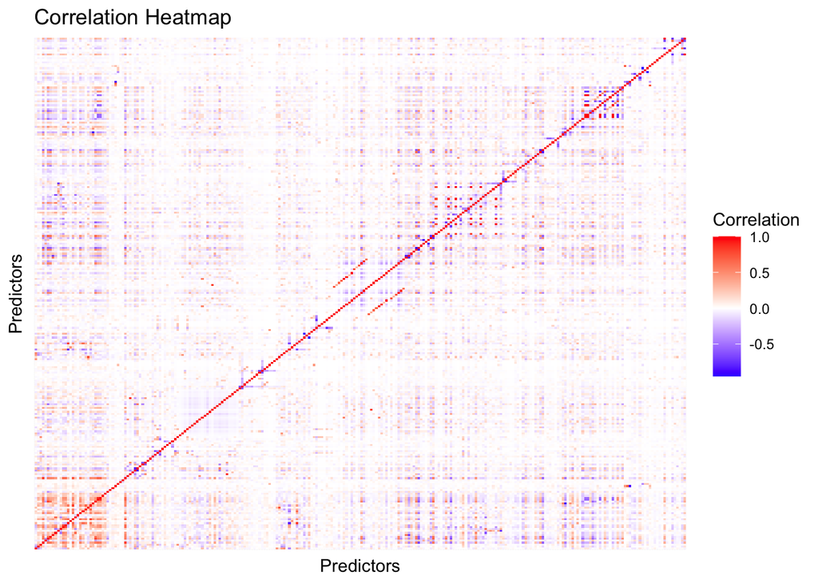

```r
library(ggplot2)
library(reshape2)

# Get categorical predictors
categorical_cols <- names(combined_data)[sapply(combined_data, is.character) | sapply(combined_data, is.factor)]

# Get numerical predictors
numeric_cols <- names(combined_data)[sapply(combined_data, is.numeric)]

# One-hot encode categorical variables
data_encoded <- as.data.frame(model.matrix(~ . - 1, data = combined_data[categorical_cols]))

# Combine numeric and encoded categorical variables
data_combined <- cbind(combined_data[numeric_cols], data_encoded)

# Compute correlation matrix
cor_matrix <- cor(data_combined, use = "pairwise.complete.obs")

# Melt correlation matrix for ggplot2
cor_melt <- melt(cor_matrix)

# Generate heatmap with ggplot2
ggplot(cor_melt, aes(Var1, Var2, fill = value)) +
  geom_tile() +
  scale_fill_gradient2(low = "blue", mid = "white", high = "red", midpoint = 0) +
  theme_minimal() +
  theme(
    axis.text.x = element_blank(),  # Remove x-axis labels
    axis.text.y = element_blank()   # Remove y-axis labels
  ) +
  labs(title = "Correlation Heatmap", x = "Predictors", y = "Predictors", fill = "Correlation")
```

From the above plot, it is clear that many predictors are strongly linearly correlated. Because of this, we are interested in models that can handle multicollinearity. We will examine the following before choosing a final model to predict with:

- LASSO
- Ridge
- PLS
- PCR